# Unsupervised Learning (clustering)

Day 18

## Supervised Learning:

- Classify a response `y` into 3 classes based on their `x1` and `x2` values:

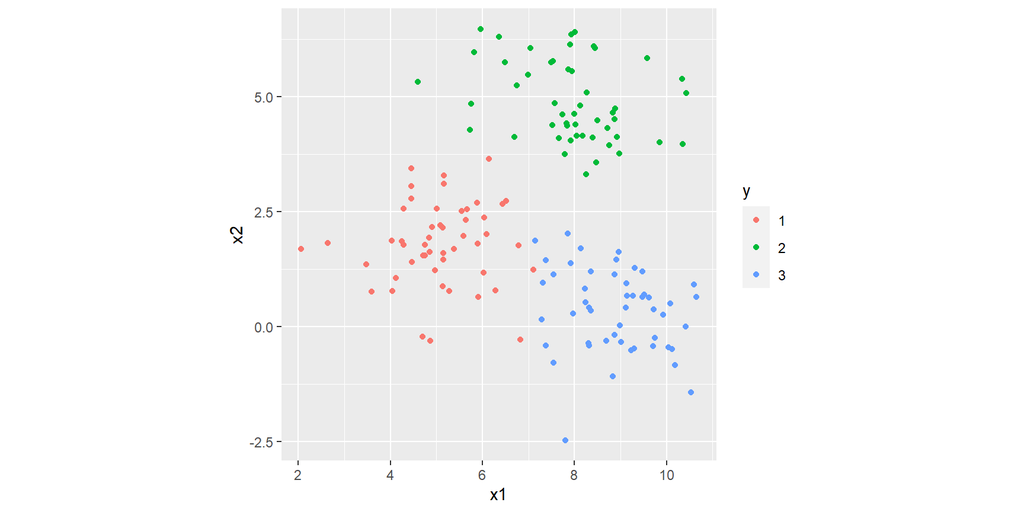

- What method would we use?

## A different type of classification problem:

- Suppose we **only** have data on `x1` and `x2` and want to classify the `n` data cases:

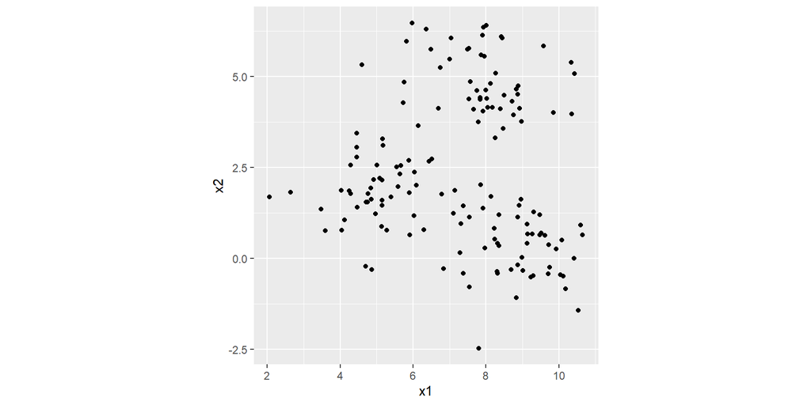

## Unsupervised Learning

- This is an example of an unsupervised learning problem
  - there is no classification response to judge how well we classify the data!
  - e.g. we don’t have a training data set available to train a model how to classify
- What are some examples of clustering problems?
  - Finding natural cutoff in letter grades based on scores
  - Grouping schools based on student characteristics
  - Grouping products/companies based on characterstics
- We will focus on two methods
  - K-means clustering: group cases into \(K\) (fixed) groups based on the similarity of their X-variable values.
  - Hierarchical clustering: produce a tree that illustrates “closeness” of cases (in terms of X-variables), cut the tree to classify into groups

## Unsupervised Learning example

- Imagine aliens know the long/lat of major cities but have no idea how to group them
- If we choose 6 clusters, we get pretty good continent groupings

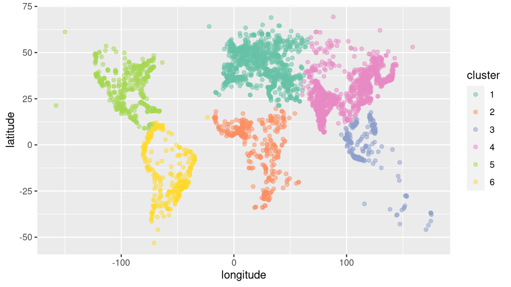

## K-means clustering

- Goal: Produce \(K\) different clusters that have “similar values”
- We have a set of (predictor) variables for n cases
  - for case i: \(X_{i1}, ..., X_{ip}\)
- Definition: \(C_k\) is a set of indices that tell us which cases are in cluster \(k\)
  - e.g. \(C_1 = {3,6,10}\) tell us that cases 3, 6, and 10 are in cluster 1.
- Definition: \(|C_k|\) is the size of cluster \(C_k\)
  - can range from \(1\) to \(n\)

## K-means clustering

- How to measure “similar variable values”?
  - one (common) way: Euclidean distance between cases in the same cluster!
  - **within cluster variation** (distance): for cluster \(C_k\) \[ W_k = \dfrac{\sum_{i,l \in C_k} (x_{i1} - x_{l1})^2 + (x_{i2} - x_{l2})^2 + \cdots + (x_{ip} - x_{lp})^2}{|C_k|} \]
- The optimal cluster assignment \(C_1,...,C_K\) will minimize the total within cluster variation: \[ \min_{C_1,...,C_K} \sum_{k=1}^K W_k \]

## K-means algorithm

- Counting fact: How many ways to partition (cluster) n cases into \(K\) groups?
  - approximately \(K^n\) (Growing exponentially)
  - calculating the minimum distances for all possible combinations will take too long
- With any real data problem, we need to use a computer algorithm to (hopefully) get us close to the optimal cluster assignment

## K-means algorithm

`1.` Randomly assign \(K\) classes to each case.

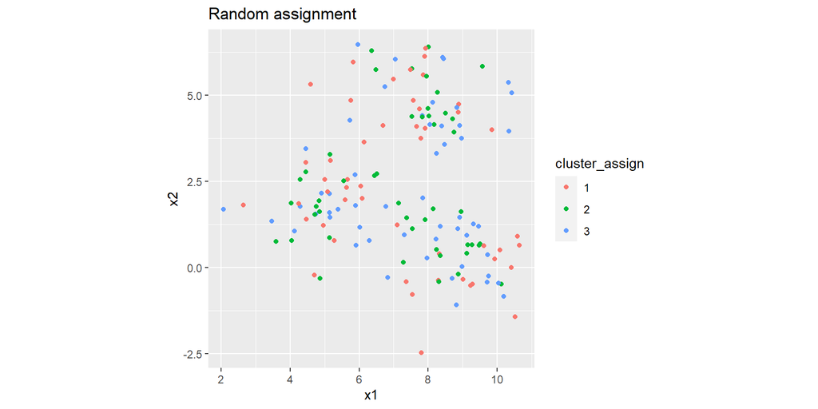

## K-means algorithm

`2.` Compute the *centroid* of each cluster:

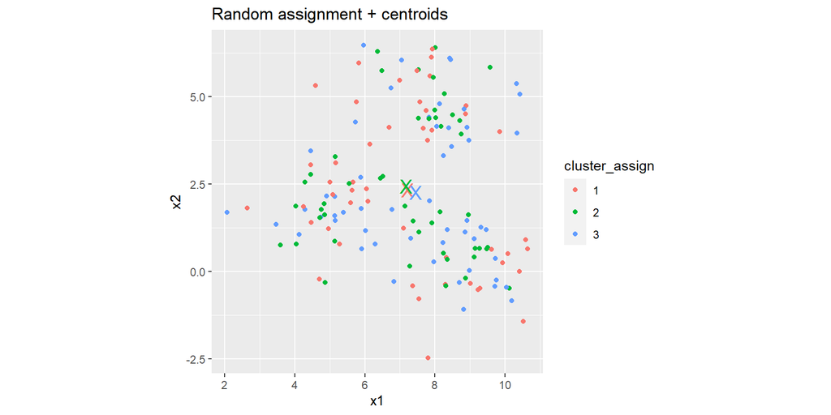

## K-means algorithm

`3.` Reassign cases to the cluster whose centroid they are closest to.

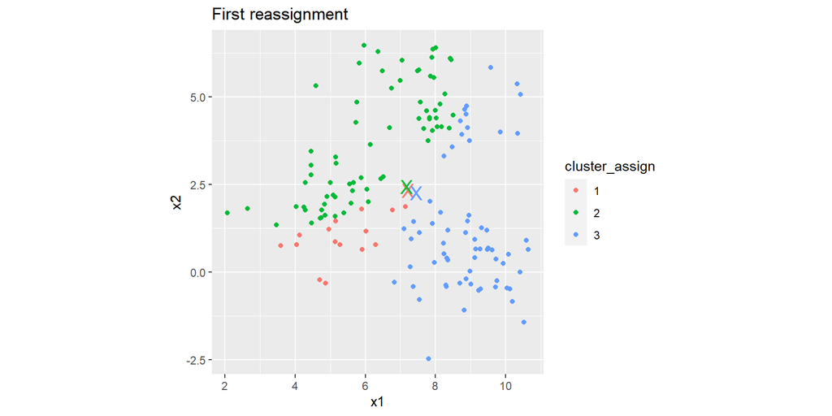

## K-means algorithm

`4.` Repeat `2-3` until no more cases are reassigned to a new cluster.

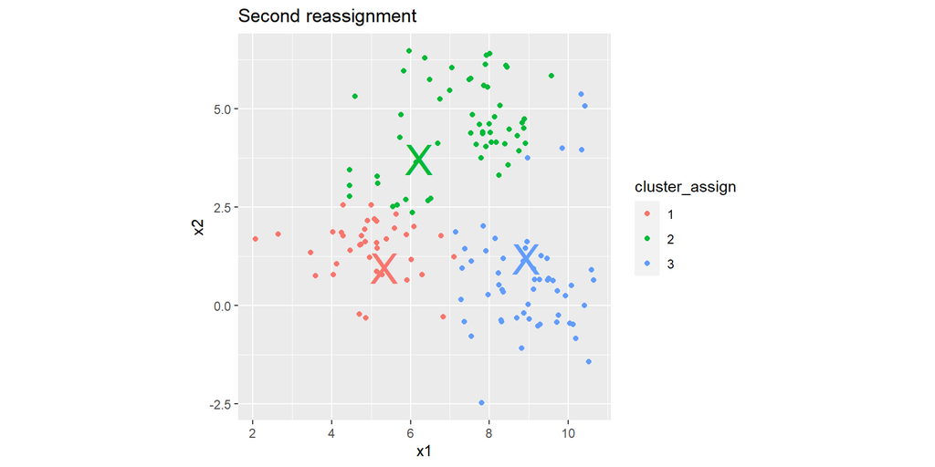

## K-means algorithm

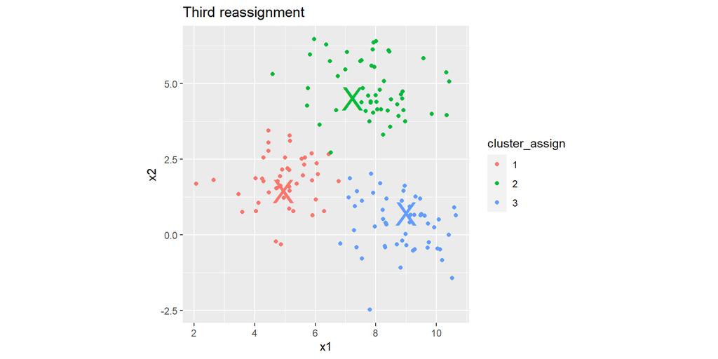

## K-means algorithm

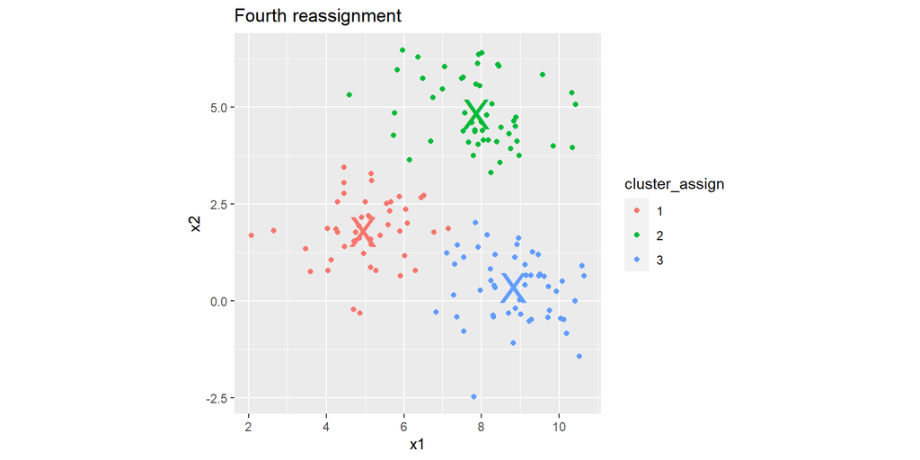

## K-means algorithm

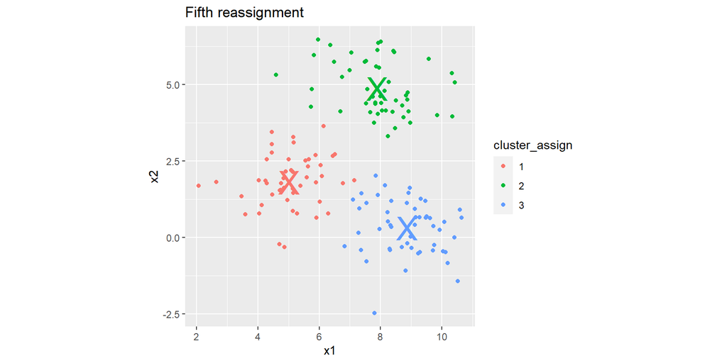

## K-means algorithm

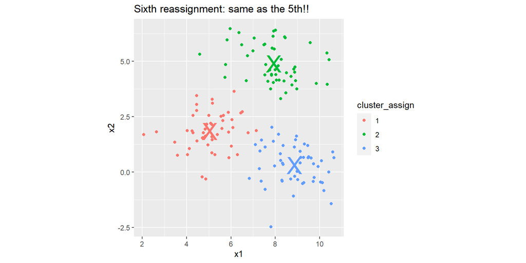

- Took 5 iterations to converge (no new reassignments!)

## K-means algorithm

- This algorithm is *locally optimal*
  - reduces the *total within cluster variation* at each step (why?)
- But it is not necessarily *globally optimal*
  - solution depends on the random starting point (step I)
- In practice:
  - repeat the algorithm 20-50 times
  - use the **best** clustering assignment (e.g. smallest total within cluster variation)
  - also use `set.seed` to make results reproducible!

## K-means in R

- `kmeans(x, centers, iter.max, nstart)` function in base-R:
  - `x` is a matrix or data frame of variables (must be numeric!)
  - `centers` value of \(K\)
  - `iter.max` number of iterations (default is 10)
  - `nstart` number of random starting assignments (step I), default is 1 so always change this to a higher number
- output: `km_out <- kmeans(...)`
  - `km_out$cluster` is an integer vector of cluster assignments
  - `km_out$tot.withinss` is total within cluster variation (sum of squares)
  - `km_out$centers` a \(k \times p\) matrix of cluster centers

## K-means in R

- Let’s use `kmeans` on the simulated data with \(K=3\)

```r
> head(clus_data[,1:2])
# A tibble: 6 × 2
     x1    x2
  <dbl> <dbl>
1  4.45  2.78
2  6.09  2.01
3  5.64  2.32
4  6.04  2.37
5  5.17  3.11
6  6.14  3.64
> set.seed(18)
> km_out <- kmeans(clus_data[,1:2], centers=3, nstart=20)
```

## K-means in R

Let’s add cluster assignment to the data frame:

```r
> clus_data <- clus_data %>% mutate(cluster_assign = as.character(km_out$cluster))
> head(clus_data)
# A tibble: 6 × 3
     x1    x2 cluster_assign
  <dbl> <dbl> <chr>
1  4.45  2.78 2
2  6.09  2.01 2
3  5.64  2.32 2
4  6.04  2.37 2
5  5.17  3.11 2
6  6.14  3.64 2
```

## K-means in R

- Now we can see the assignment:

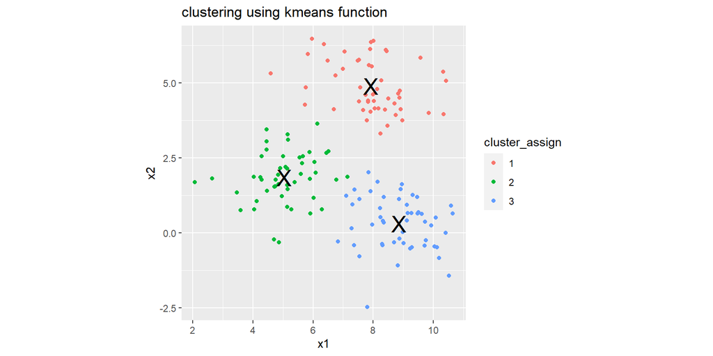

## K-means in R

- The centroids for this fit are:

```r
> km_out$centers
        x1        x2
1 7.929049 4.9001490
2 5.045878 1.8511803
3 8.857231 0.3173005
```

## What if we use 6 clusters?

- Let’s see what happens if we use 6 clusters:

```r
> set.seed(18)
> km_out6 <- kmeans(clus_data[,1:2], centers=6, nstart=20)
> clus_data <- clus_data %>% mutate(cluster_assign6 = as.character(km_out6$cluster))
> head(clus_data)
# A tibble: 6 × 4
     x1    x2 cluster_assign cluster_assign6
  <dbl> <dbl> <chr>          <chr>
1  4.45  2.78 2              2
2  6.09  2.01 2              2
3  5.64  2.32 2              2
4  6.04  2.37 2              2
5  5.17  3.11 2              2
6  6.14  3.64 2              2
```

## What if we use 6 clusters?

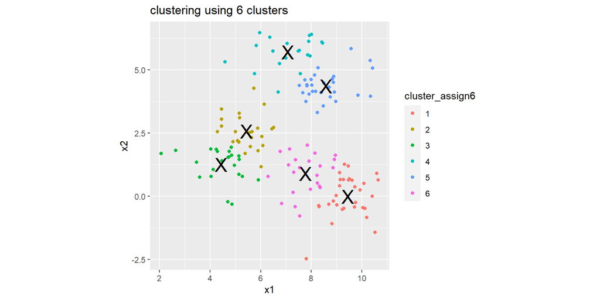

## What if we use 6 clusters?

- Which solution will have *smaller* total within cluster variation?

```r
> km_out$tot.withinss
[1] 278.9217
> km_out6$tot.withinss
[1] 157.7354
```

- Increasing the number of clusters will always decrease the within cluster variation
  - if \(K=n\) then within cluster variation is 0!
- If we are uncertain how many “groups” are in our data/population, we can pick \(K\) that shows the biggest reduction in total variation

## Within cluster SS vs. \(K\)

- We look for an “elbow” in the plot: \(K=3\) is when total \(W_k\) starts leveling off
  - more than 3 clusters complicates analysis with little reduction in SS

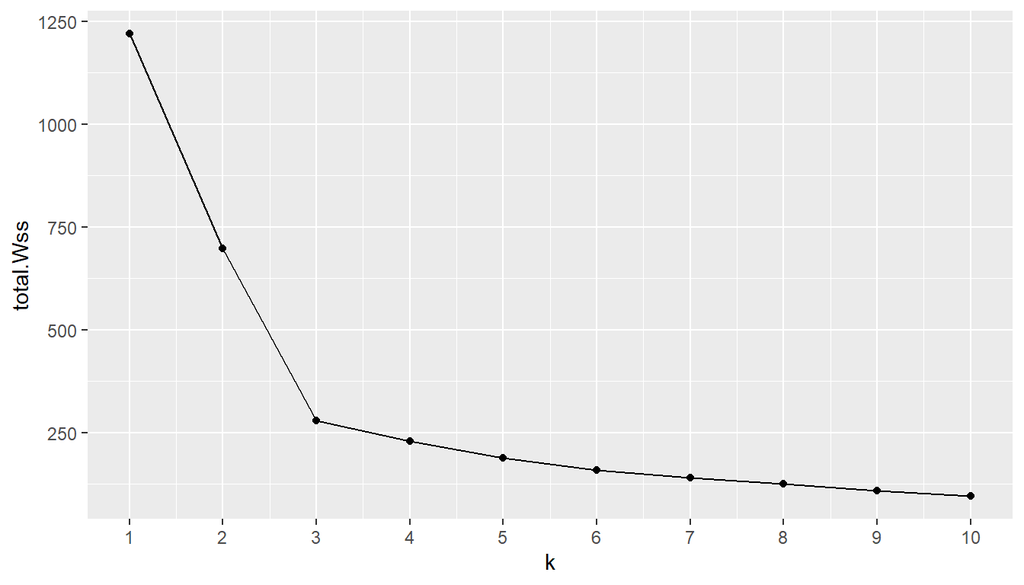

## Example 2

- Same data: just multiplied `x2` by 1000!

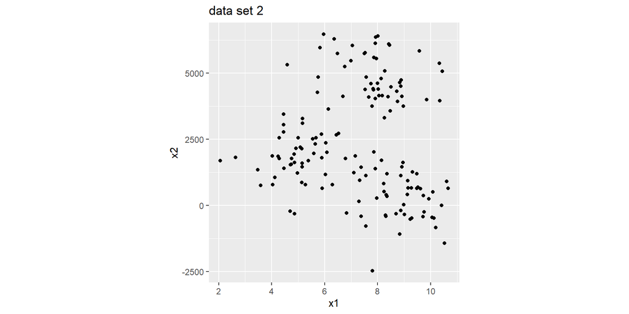

## Example 2

- Fit kmeans with \(K=3\). Why the difference in cluster assignments?!

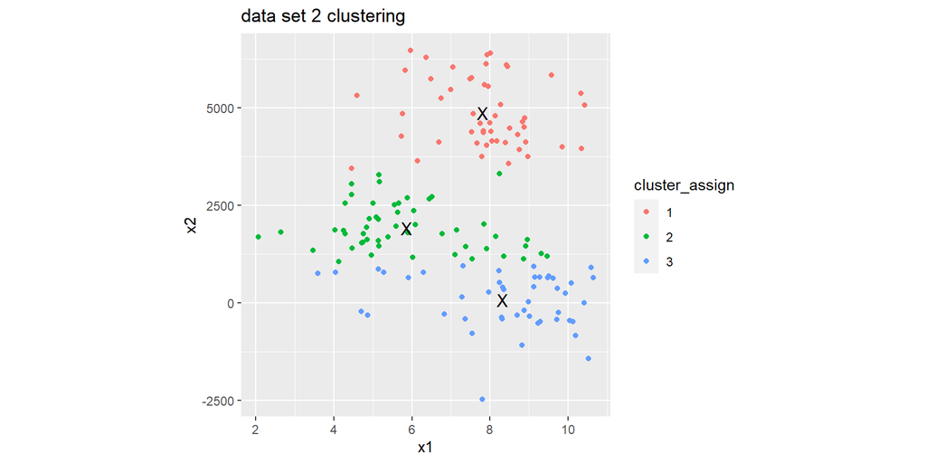

## Standardizing

- k-means uses Euclidean distance to determine closeness (SS/variation) of points.
  - just like k-nn
- if you want to treat variables “equally” in the algorithm, you need to standardize if they differ greatly in scale/variation

## Example 2 - standarized

- Now assignments match much better with the original data (and our intuition on “where” the clusters lie)

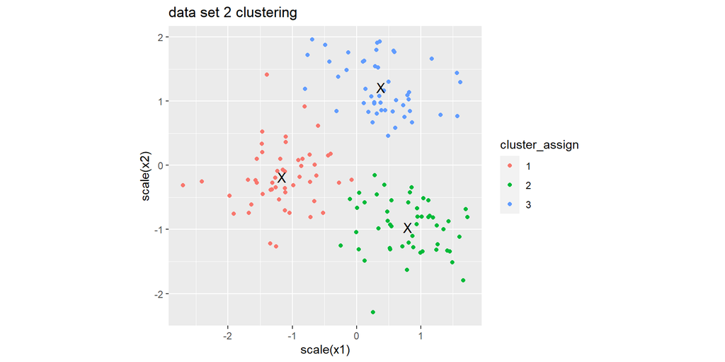

## After clustering

- Clustering is often used as an exploratory tool
  - always standardize variables!
- Use EDA tools to compare different characteristics of clusters
- Example: peer school groups
  - use cluster analysis to find high schools with similar demographics
  - identify the cluster that contains Claremont schools (“peer” schools)
  - Claremont teachers: can use the other schools in this cluster as “comparison” schools (e.g. for test scores, etc)
- One downside is that you need to specify the number of clusters beforehand